# ML_final_poject_done

## Part 1: Loading and Preparing MNIST

Code is provided below to you to load MNIST for your own training.

```python
import pandas as pd
import numpy as np

import matplotlib.pyplot as plt
import seaborn as sns

from sklearn.model_selection import train_test_split
from sklearn.metrics import confusion_matrix

import keras
from keras.models import Sequential
from keras.layers import Conv2D, Lambda, MaxPooling2D # convolution layers
from keras.layers import Dense, Dropout, Flatten # core layers


from keras.preprocessing.image import ImageDataGenerator

from keras.utils.np_utils import to_categorical
```

```python
# example of loading the mnist dataset
from tensorflow.keras.datasets import mnist
from matplotlib import pyplot as plt
# load dataset
(trainX, trainy), (testX, testy) = mnist.load_data()
# summarize loaded dataset
print('Train: X=%s, y=%s' % (trainX.shape, trainy.shape))
print('Test: X=%s, y=%s' % (testX.shape, testy.shape))
```

```
Downloading data from https://storage.googleapis.com/tensorflow/tf-keras-datasets/mnist.npz
Train: X=(60000, 28, 28), y=(60000,)
Test: X=(10000, 28, 28), y=(10000,)
```

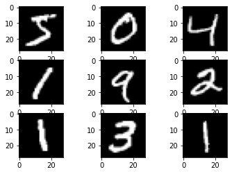

```python
# plot first few images
for i in range(9):
	# define subplot
	plt.subplot(330 + 1 + i)
	# plot raw pixel data
	plt.imshow(trainX[i], cmap=plt.get_cmap('gray'))
# show the figure
plt.show()
```

### Part 1.1: Preparing MNIST and the Collected Handwritten Digits for Training

Here you will implement any data preparation steps needed to prepare the MNIST data for training and validation, and you will prepare the class's Handwritten Digit Data Set so that it is formatted in the same way.

```python
# load dataset
(trainX, trainY), (testX, testY) = mnist.load_data()
# reshape dataset to have a single channel
trainX = trainX.reshape((trainX.shape[0], 28, 28, 1))
testX = testX.reshape((testX.shape[0], 28, 28, 1))
```

```python
trainX = trainX.reshape((trainX.shape[0], 28, 28, 1))
testX = testX.reshape((testX.shape[0], 28, 28, 1))
```

```python
# one hot encode target values
trainY = to_categorical(trainY)
testY = to_categorical(testY)
```

```python
# convert from integers to floats
train_norm = trainX.astype('float32')
test_norm = testX.astype('float32')
# normalize to range 0-1
# CNN converg faster on [0..1] data than on [0..255].
train_norm = train_norm / 255.0
test_norm = test_norm / 255.0
```

```python
trainX.shape, testX.shape, trainY.shape, testY.shape
```

```
((60000, 28, 28, 1), (10000, 28, 28, 1), (60000, 10), (10000, 10))
```

Load the class's Handwritten Digit Data Set:

```python
handwritten= pd.read_csv('/content/combined_digits_1.csv')
```

Process the class's Handwritten Digit Data Set into a matrix containing one row per image, and 28*28 (784) columns. Consider converting to gray scale, resizing and rotating images where necessary. Background pixels should contain values of 0 while pixels with writing should contain values near 255:

```python
handwrittenY= handwritten['LABEL'].values
handwrittenX= handwritten.drop(['LABEL'],1).values
```

```python
h_train_x, h_test_x, h_train_y, h_test_y= train_test_split(handwrittenX,handwrittenY, random_state=33)
```

```python
h_train_x = h_train_x.reshape((h_train_x.shape[0], 28, 28, 1))
h_test_x = h_test_x.reshape((h_test_x.shape[0], 28, 28, 1))
h_train_y = to_categorical(h_train_y)
h_test_y = to_categorical(h_test_y)
```

Perform any pre-modeling processing. Consider that 2-D Convolution and Pooling operate on un-flattened data. If appropriate, process each of the MNIST Training and Testing data sets, and the Handwritten Digits data into a 4-D Tensor of dimensions (N,28,28,1), representing N images in each set, 28 rows and columns per image, and one color channel (gray scale):

### Part 1.2: Train and Validate your Model

Design your model below, Training and Validating with the MNIST Training and MNIST Testing data sets respectively.

```python
model=Sequential()

#model.add(Lambda(standardize,input_shape=(28,28,1)))
model.add(Conv2D(filters=64, kernel_size = (3,3), activation="relu", input_shape=(28,28,1)))
model.add(Conv2D(filters=64, kernel_size = (3,3), activation="relu"))
model.add(MaxPooling2D(pool_size=(2,2)))

model.add(Conv2D(filters=128, kernel_size = (3,3), activation="relu"))
model.add(Conv2D(filters=128, kernel_size = (3,3), activation="relu"))
model.add(MaxPooling2D(pool_size=(2,2)))


model.add(Conv2D(filters=256, kernel_size = (3,3), activation="relu"))
model.add(MaxPooling2D(pool_size=(2,2)))


model.add(Flatten())
model.add(Dense(512,activation="relu"))

model.add(Dense(10,activation="softmax"))

model.compile(loss="categorical_crossentropy", optimizer="adam", metrics=["accuracy"])
```

```python
model.summary()
```

```
Model: "sequential"
_________________________________________________________________
 Layer (type)                Output Shape              Param #
=================================================================
 conv2d (Conv2D)             (None, 26, 26, 64)        640

 conv2d_1 (Conv2D)           (None, 24, 24, 64)        36928

 max_pooling2d (MaxPooling2D  (None, 12, 12, 64)       0
 )

 conv2d_2 (Conv2D)           (None, 10, 10, 128)       73856

 conv2d_3 (Conv2D)           (None, 8, 8, 128)         147584

 max_pooling2d_1 (MaxPooling  (None, 4, 4, 128)        0
 2D)

 conv2d_4 (Conv2D)           (None, 2, 2, 256)         295168

 max_pooling2d_2 (MaxPooling  (None, 1, 1, 256)        0
 2D)

 flatten (Flatten)           (None, 256)               0

 dense (Dense)               (None, 512)               131584

 dense_1 (Dense)             (None, 10)                5130

=================================================================
Total params: 690,890
Trainable params: 690,890
Non-trainable params: 0
_________________________________________________________________
```

```python
# With data augmentation to prevent overfitting

datagen = ImageDataGenerator(
        featurewise_center=False,  # set input mean to 0 over the dataset
        samplewise_center=False,  # set each sample mean to 0
        featurewise_std_normalization=False,  # divide inputs by std of the dataset
        samplewise_std_normalization=False,  # divide each input by its std
        zca_whitening=False,  # apply ZCA whitening
        rotation_range=15,  # randomly rotate images in the range (degrees, 0 to 180)
        zoom_range = 0.01, # Randomly zoom image
        width_shift_range=0.1,  # randomly shift images horizontally (fraction of total width)
        height_shift_range=0.1,  # randomly shift images vertically (fraction of total height)
        horizontal_flip=False,  # randomly flip images
        vertical_flip=False)  # randomly flip images


#datagen.fit(X_train)
train_gen = datagen.flow(trainX, trainY, batch_size=128)
test_gen = datagen.flow(testX, testY, batch_size=128)
h_train_gen=datagen.flow(h_train_x, h_train_y, batch_size=128)
h_test_gen = datagen.flow(h_test_x, h_test_y, batch_size=128)
```

```python
epochs = 10
batch_size = 128
train_steps = trainX.shape[0] // batch_size
valid_steps = testX.shape[0] // batch_size
```

```python
# Fit the model
history = model.fit_generator(train_gen,
                              epochs = epochs,
                              steps_per_epoch = train_steps,
                              validation_data = test_gen,
                              validation_steps = valid_steps)
```

[output not shown]